# Eksplorativna analiza podataka (Exploratory Data Analysis - EDA) u R-u: Studija slucaja - UN Voting Dataset

Igor Hut

09 January, 2017

## Uvodna razmatranja

- Izvor: *Erik Voeten, “Data and Analyses of Voting in the UN General Assembly”*
- Svi podaci su dostupni u okviru R paketa “unvote”: https://cran.r-project.org/web/packages/unvotes/
- Kao i u GitHub repozitorujumu: https://github.com/dgrtwo/unvotes
- Sadrzani podaci se odnose na istoriju glasanja zemalja clanica na Generalnoj skupstini Ujedinjenih nacija. Date su informacije o datumu glasanja, temi o kojoj se glasalo i kako je svaka od zemalja glasala.

### Setovi podataka

`unvotes` R paket sadrzi tri seta podataka u formi data frame-a (preciznije tbl_df, odn. tibble, sto obezbedjuje bolje formatiranje pri njihovom ispisivanju). Prvi set podataka, `un_votes` se odnosi na istoriju glasanja svake od zemalja. Svaka vrsta sadrzi country/vote par:

```r
library(dplyr)
library(unvotes)
str(un_votes)
```

```
## Classes 'tbl_df', 'tbl' and 'data.frame':    711275 obs. of  3 variables:
##  $ rcid   : atomic  3 3 3 3 3 3 3 3 3 3 ...
##   ..- attr(*, "comment")= chr "rcid"
##  $ country: chr  "Egypt" "Honduras" "Costa Rica" "El Salvador" ...
##  $ vote   : Factor w/ 3 levels "abstain","no",..: 1 3 3 3 2 3 3 3 3 3 ...
```

```r
un_votes
```

```
## # A tibble: 711,275 × 3
##     rcid     country    vote
##    <dbl>       <chr>  <fctr>
## 1      3       Egypt abstain
## 2      3    Honduras     yes
## 3      3  Costa Rica     yes
## 4      3 El Salvador     yes
## 5      3      France      no
## 6      3     Uruguay     yes
## 7      3       Chile     yes
## 8      3     Ecuador     yes
## 9      3   Argentina     yes
## 10     3       Haiti     yes
## # ... with 711,265 more rows
```

Paket takodje sadrzi i set podataka sa informacijama o svakom javnom glasanju, ukljucujuci datum, opis, i rezoluciju o kojoj je glasano:

```r
un_roll_calls
```

```
## # A tibble: 5,356 × 9
##     rcid session importantvote       date   unres amend  para
##    <dbl>   <dbl>         <dbl>     <date>   <chr> <dbl> <dbl>
## 1      3       1             0 1946-01-01  R/1/66     1     0
## 2      4       1             0 1946-01-02  R/1/79     0     0
## 3      5       1             0 1946-01-04  R/1/98     0     0
## 4      6       1             0 1946-01-04 R/1/107     0     0
## 5      7       1             0 1946-01-02 R/1/295     1     0
## 6      8       1             0 1946-01-05 R/1/297     1     0
## 7      9       1             0 1946-02-05 R/1/329     0     0
## 8     10       1             0 1946-02-05 R/1/361     1     1
## 9     11       1             0 1946-02-05 R/1/376     0     0
## 10    12       1             0 1946-02-06 R/1/394     1     1
## # ... with 5,346 more rows, and 2 more variables: short <chr>, descr <chr>
```

Konacno `un_roll_call_issues` set podataka sadrzi informacije o medjusobnoj povezanosti razlicitih glasanja kao i o 6 generalnih problema o kojima je glasano u Gen. skupstini UN-a:

```r
un_roll_call_issues
```

```
## # A tibble: 4,951 × 3
##     rcid short_name                issue
##    <dbl>      <chr>                <chr>
## 1     30         me Palestinian conflict
## 2     34         me Palestinian conflict
## 3     77         me Palestinian conflict
## 4   9002         me Palestinian conflict
## 5   9003         me Palestinian conflict
## 6   9004         me Palestinian conflict
## 7   9005         me Palestinian conflict
## 8   9006         me Palestinian conflict
## 9    128         me Palestinian conflict
## 10   129         me Palestinian conflict
## # ... with 4,941 more rows
```

```r
count(un_roll_call_issues, issue, sort = TRUE)
```

```
## # A tibble: 6 × 2
##                                  issue     n
##                                  <chr> <int>
## 1                 Palestinian conflict  1047
## 2                          Colonialism   971
## 3                         Human rights   901
## 4         Arms control and disarmament   859
## 5 Nuclear weapons and nuclear material   712
## 6                 Economic development   461
```

Za vise informacija o svakom od pojedinacnih setova podataka koristite naredbu `help()`.

## Priprema podataka za analizu

Za pocetak cemo da izvrsimo “inner join” za setove `un_votes` i `un_roll_calls` a na osnovu zajednicke kolone `rcid`. Na ovaj nacin dobijamo objedinjen set podataka sa vecinom informacija relevantnih za dalju eksplorativnu analizu.

```r
joined <- inner_join(un_votes, un_roll_calls, by = "rcid")

joined
```

```
## # A tibble: 711,275 × 11
##     rcid     country    vote session importantvote       date  unres amend
##    <dbl>       <chr>  <fctr>   <dbl>         <dbl>     <date>  <chr> <dbl>
## 1      3       Egypt abstain       1             0 1946-01-01 R/1/66     1
## 2      3    Honduras     yes       1             0 1946-01-01 R/1/66     1
## 3      3  Costa Rica     yes       1             0 1946-01-01 R/1/66     1
## 4      3 El Salvador     yes       1             0 1946-01-01 R/1/66     1
## 5      3      France      no       1             0 1946-01-01 R/1/66     1
## 6      3     Uruguay     yes       1             0 1946-01-01 R/1/66     1
## 7      3       Chile     yes       1             0 1946-01-01 R/1/66     1
## 8      3     Ecuador     yes       1             0 1946-01-01 R/1/66     1
## 9      3   Argentina     yes       1             0 1946-01-01 R/1/66     1
## 10     3       Haiti     yes       1             0 1946-01-01 R/1/66     1
## # ... with 711,265 more rows, and 3 more variables: para <dbl>,
## #   short <chr>, descr <chr>
```

## Eksplorativna analiza

#### Koliko ukupno ima glasova, za sva glasanja i sve godine, i koliko je procentualno bilo glasova “za” u odnosu na ukupan broj glasova?

```r
summarise(joined, total = n(), percent_yes = mean(vote == "yes"))
```

```
## # A tibble: 1 × 2
##    total percent_yes
##    <int>       <dbl>
## 1 711275   0.7963952
```

#### Kako su glasale pojedinacne zemlje, u proseku, tokom istorije Gen. skupstine UN?

```r
by_country <- joined %>%
    group_by(country) %>%
    summarise(n_votes = n(),
            percent_yes = mean(vote == "yes"))

# Print the by_country dataset
by_country
```

```
## # A tibble: 200 × 3
##                country n_votes percent_yes
##                  <chr>   <int>       <dbl>
## 1          Afghanistan    4824   0.8381012
## 2              Albania    3363   0.7204877
## 3              Algeria    4374   0.8978052
## 4              Andorra    1410   0.6510638
## 5               Angola    2950   0.9223729
## 6  Antigua and Barbuda    2521   0.9170964
## 7            Argentina    5207   0.7743422
## 8              Armenia    1479   0.7592968
## 9            Australia    5245   0.5542421
## 10             Austria    4786   0.6320518
## # ... with 190 more rows
```

```r
arrange(by_country, percent_yes)
```

```
## # A tibble: 200 × 3
##                            country n_votes percent_yes
##                              <chr>   <int>       <dbl>
## 1                         Zanzibar       2   0.0000000
## 2                    United States    5237   0.2850869
## 3                            Palau     777   0.3063063
## 4                           Israel    4790   0.3503132
## 5      Federal Republic of Germany    2151   0.3984193
## 6  Micronesia, Federated States of    1341   0.4131245
## 7                   United Kingdom    5218   0.4269835
## 8                           France    5171   0.4320248
## 9                 Marshall Islands    1468   0.4788828
## 10                         Belgium    5238   0.4925544
## # ... with 190 more rows
```

```r
arrange(by_country, desc(percent_yes))
```

```
## # A tibble: 200 × 3
##                  country n_votes percent_yes
##                    <chr>   <int>       <dbl>
## 1             Seychelles    1698   0.9770318
## 2            Timor-Leste     697   0.9670014
## 3  Sao Tome and Principe    2329   0.9665092
## 4               Djibouti    3193   0.9564673
## 5          Guinea-Bissau    2933   0.9546539
## 6                Comoros    2435   0.9462012
## 7             Cabo Verde    3153   0.9454488
## 8             Mozambique    3306   0.9431337
## 9                  Yemen    1527   0.9423707
## 10              Zimbabwe    2766   0.9421547
## # ... with 190 more rows
```

```r
arrange(by_country, n_votes)
```

```
## # A tibble: 200 × 3
##        country n_votes percent_yes
##          <chr>   <int>       <dbl>
## 1     Zanzibar       2   0.0000000
## 2     Kiribati      93   0.8172043
## 3  South Sudan      96   0.6979167
## 4   Montenegro     558   0.6433692
## 5       Tuvalu     576   0.8246528
## 6        Nauru     606   0.6089109
## 7  Timor-Leste     697   0.9670014
## 8        Tonga     775   0.7303226
## 9        Palau     777   0.3063063
## 10 Switzerland     857   0.6569428
## # ... with 190 more rows
```

Moze se primetiti da ima nekoliko zemalja koje su znacajno manje puta ucestvovale u glasanju od ostalih (Zanzibar, Kiribati, South Sudan). Ove zemlje i podatke vezane za njih cemo izostatiti iz buduce analize. Filterujemo set podataka tako da izostavimo sve zemlje koje su glasale manje od 100 puta:

```r
by_country %>%
filter( n_votes > 100) %>%
  arrange(percent_yes)
```

```
## # A tibble: 197 × 3
##                            country n_votes percent_yes
##                              <chr>   <int>       <dbl>
## 1                    United States    5237   0.2850869
## 2                            Palau     777   0.3063063
## 3                           Israel    4790   0.3503132
## 4      Federal Republic of Germany    2151   0.3984193
## 5  Micronesia, Federated States of    1341   0.4131245
## 6                   United Kingdom    5218   0.4269835
## 7                           France    5171   0.4320248
## 8                 Marshall Islands    1468   0.4788828
## 9                          Belgium    5238   0.4925544
## 10                      Luxembourg    5169   0.5105436
## # ... with 187 more rows
```

#### Kako se menjao generalni trend glasanja kroz istoriju?

```r
library(lubridate)
by_year <- joined %>%
  group_by(year = year(date)) %>%
  summarize(n_votes = n(),
            percent_yes = mean(vote == "yes")) %>%
  filter( n_votes > 100)

by_year
```

```
## # A tibble: 68 × 3
##     year n_votes percent_yes
##    <dbl>   <int>       <dbl>
## 1   1946    2143   0.5734951
## 2   1947    2039   0.5693968
## 3   1948    3454   0.3998263
## 4   1949    5700   0.4254386
## 5   1950    2911   0.4970800
## 6   1951     402   0.6567164
## 7   1952    4082   0.5460559
## 8   1953    1537   0.6317502
## 9   1954    1788   0.6224832
## 10  1955    2169   0.6947902
## # ... with 58 more rows
```

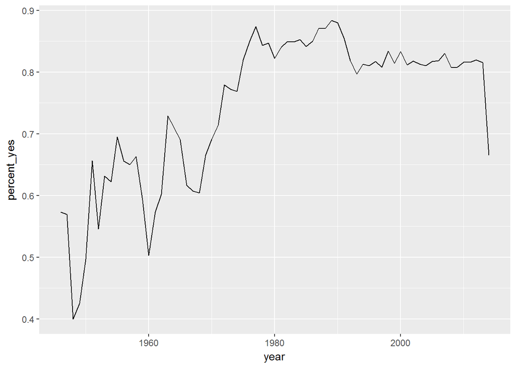

```r
# Da vizualizujemo ovaj trend pomocu linijskog grafika
library(ggplot2)
ggplot(by_year, aes(x = year, y = percent_yes)) +
  geom_line()
```

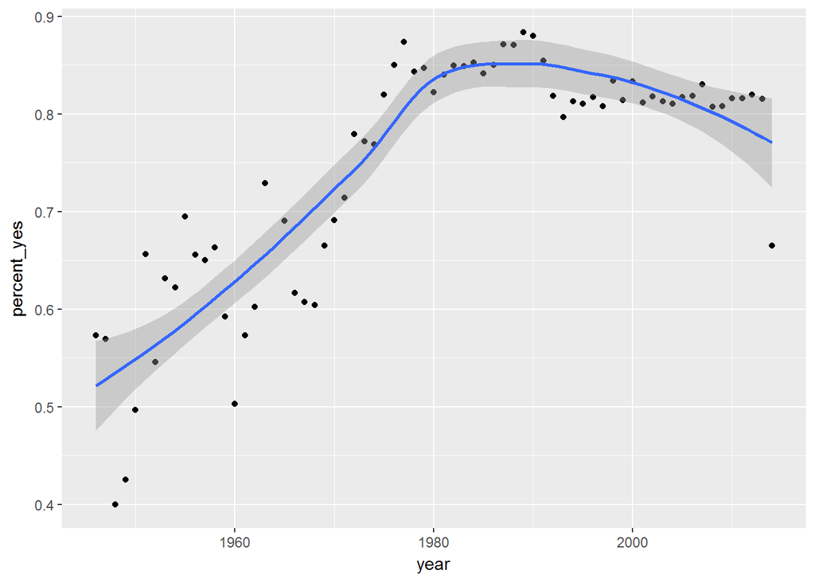

```r
# Scatter plot + geom_smooth

ggplot(by_year, aes( year, percent_yes)) +
  geom_point() +
  geom_smooth()
```

Zanimljiv trend. Neposredno nakon nakon zavrsetka Drugog svetskog rata su evidentno postojale ostre nesuglasice po mnogim pitanjima. U periodu od 80-tih godina proslog veka, pa sve do skoro, deluje kao da je postojao, gotovo, koncenzus po mnogim pitanjima, medju vecinom clanica Gen. skupstine UN.

#### Koliko cesto je svaka od zemalja glasala “za” po godinama?

```r
library(lubridate)

by_year_country <- joined %>%
  group_by( year = year(date), country) %>%
  summarise(n_votes = n(), percent_yes = mean(vote == "yes"))

by_year_country
```

```
## Source: local data frame [9,496 x 4]
## Groups: year [?]
##
##     year                         country n_votes percent_yes
##    <dbl>                           <chr>   <int>       <dbl>
## 1   1946                     Afghanistan      17   0.4117647
## 2   1946                       Argentina      43   0.6976744
## 3   1946                       Australia      43   0.5581395
## 4   1946                         Belarus      43   0.4418605
## 5   1946                         Belgium      43   0.6046512
## 6   1946 Bolivia, Plurinational State of      43   0.6976744
## 7   1946                          Brazil      43   0.6046512
## 8   1946                          Canada      42   0.6428571
## 9   1946                           Chile      43   0.6046512
## 10  1946                        Colombia      42   0.3095238
## # ... with 9,486 more rows
```

#### Kako su kroz istoriju glasale, SAD, SSSR, Rusija, Jugoslavija, Srbija i Hrvatska?

Proverimo prvo da li ima svih ovih zemalja u setu:

```r
country <- distinct(by_country, country) %>%
  arrange(country)
View(country)

inner_join(country, data.frame(country = c("Serbia", "Croatia", "United States", "Russian Federation", "Yugoslavia", "Soviet Union")))
```

```
## # A tibble: 4 × 1
##              country
##                <chr>
## 1            Croatia
## 2 Russian Federation
## 3      United States
## 4         Yugoslavia
```

Izgleda da nema ni Srbije ni SSSR-a. Posmatracemo Jugoslaviju, Rusiju, Hrvatsku i SAD:

```r
filt_countries <- filter(by_year_country, country %in% c("Croatia", "United States", "Russian Federation", "Yugoslavia"))

filt_countries
```

```
## Source: local data frame [220 x 4]
## Groups: year [68]
##
##     year            country n_votes percent_yes
##    <dbl>              <chr>   <int>       <dbl>
## 1   1946 Russian Federation      43   0.4418605
## 2   1946      United States      43   0.6046512
## 3   1946         Yugoslavia      41   0.4634146
## 4   1947 Russian Federation      38   0.5263158
## 5   1947      United States      38   0.7105263
## 6   1947         Yugoslavia      38   0.5000000
## 7   1948 Russian Federation      64   0.5312500
## 8   1948      United States      64   0.3906250
## 9   1948         Yugoslavia      64   0.5312500
## 10  1949 Russian Federation     103   0.6407767
## # ... with 210 more rows
```

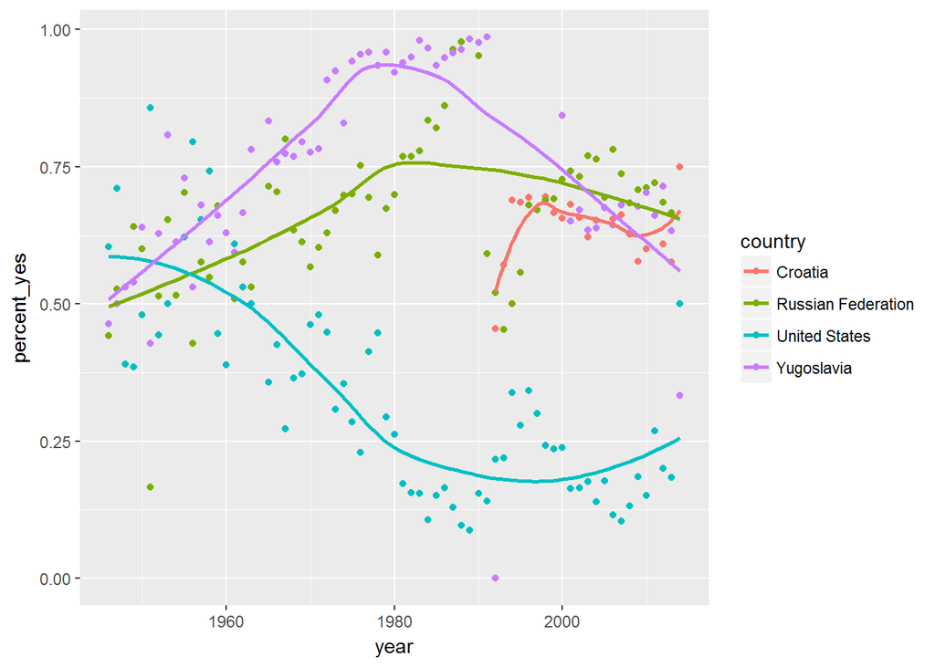

```r
ggplot(filt_countries, aes(x = year, y = percent_yes, col = country)) +
  geom_point() +
  geom_smooth(se = FALSE)
```

**Evidentno da su opservacije za Srbiju, Srbiju i Crnu Goru i Jugoslavuju deklarisane kao “Yugoslavia” a za Rusiju i SSSR kao “Russian Federation”. Zanimljivo, a donekle i ocekivano, generalni trend glasanja Ruske Federacije i Jugoslavije/ Srbije su prilicno pozitivno korelisani tokom istorije, dok je situacija sa SAD upravo suprotna. Zarad podrobnije komparacije tokom poslednje dve decenije posmatracemo samo period od 1990-te do 2014-te godine.**

```r
# Samo da jos jednom proverimo raspone vrednosti, pre svega za var. "year"
summary(filt_countries)
```

```
##       year        country             n_votes        percent_yes
##  Min.   :1946   Length:220         Min.   :  2.00   Min.   :0.0000
##  1st Qu.:1965   Class :character   1st Qu.: 54.00   1st Qu.:0.4455
##  Median :1983   Mode  :character   Median : 70.00   Median :0.6317
##  Mean   :1982                      Mean   : 75.39   Mean   :0.5812
##  3rd Qu.:2001                      3rd Qu.: 89.00   3rd Qu.:0.7159
##  Max.   :2014                      Max.   :160.00   Max.   :0.9865
```

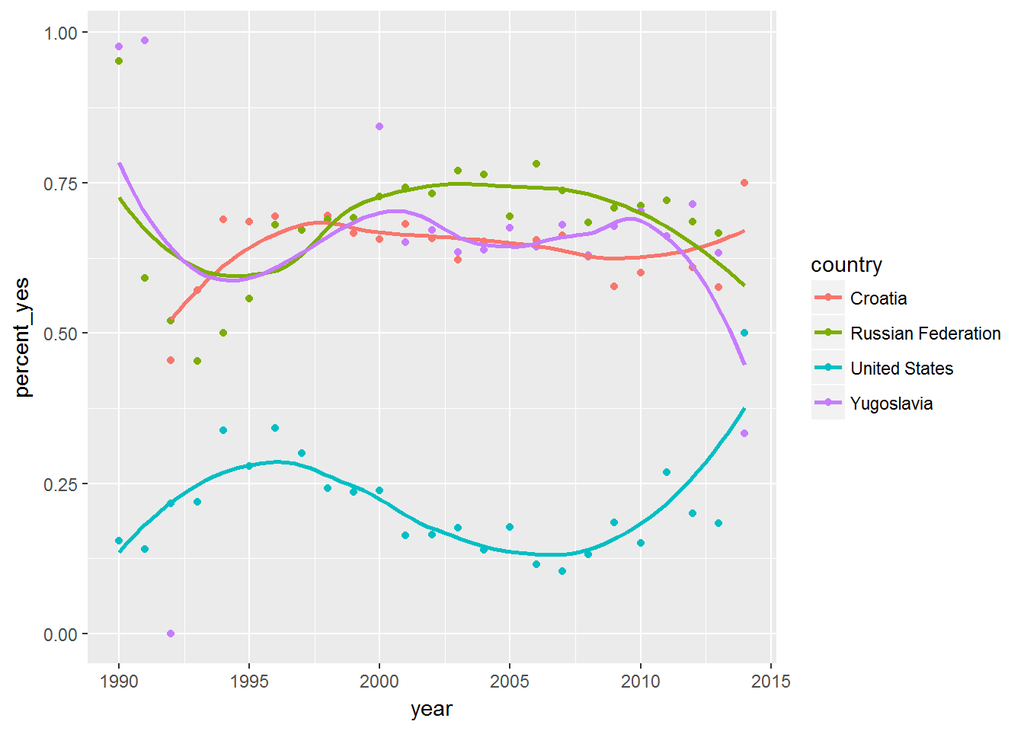

```r
ggplot(filt_countries, aes(x = year, y = percent_yes, col = country)) +
  geom_point() +
  geom_smooth(se = FALSE) +
  scale_x_continuous(limits = c(1990, 2014))
```

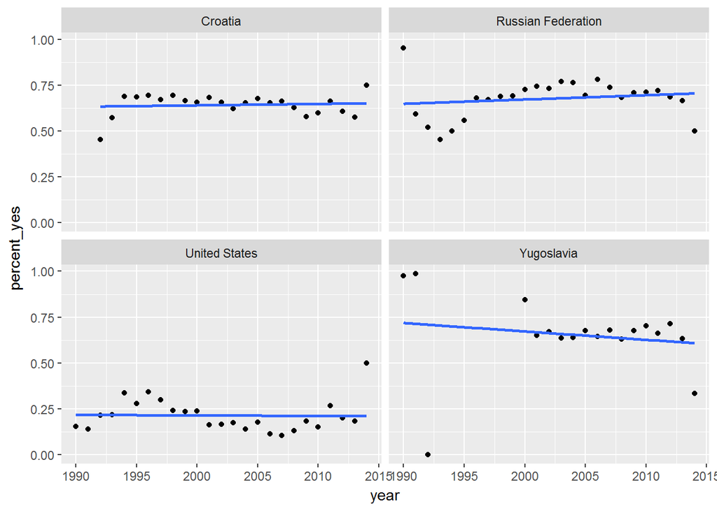

```r
ggplot(filt_countries, aes(x = year, y = percent_yes)) +
  geom_point() +
  geom_smooth(method = "lm", se = FALSE) +
  scale_x_continuous(limits = c(1990, 2014)) +
  facet_wrap( ~ country)
```

**Posmatrajuci izolovan samo period 1990-2014 god. mozemo uociti, mozda malo neocekivano, da su Srbija, Ruska Federacija i Hrvatska imale procentualno mnogo vise glasova “za” od SAD, te da se trend glasanja ove tri zemlje prilicno poklapa u datom periodu. Sta vise ovo pogotovo vazi za Hrvatsku i Rusku Federaciju. Naravno potrebno je dataljnije utvrditi kako je glasano za pojedinacne rezolucije pre nego sto izvucemo bilo kakve zakljucke.**

#### Kako je svaka od izabranih zemalja glasala tokom vremena o generalnim problemima sadrzanim u `un_roll_call_issues?

Prvo da proverimo o kojim se problemima tacno radi:

```r
distinct(un_roll_call_issues, issue)
```

```
## # A tibble: 6 × 1
##                                  issue
##                                  <chr>
## 1                 Palestinian conflict
## 2 Nuclear weapons and nuclear material
## 3         Arms control and disarmament
## 4                         Human rights
## 5                          Colonialism
## 6                 Economic development
```

Nazalost u ovom setu nema podataka o glasanjima koja su se direktno ticala politickih desavanaja na prostoru bivse Jugoslavije, sto bi nama bilo posebno zanimljivo. Elem, nastavimo sa analizom:

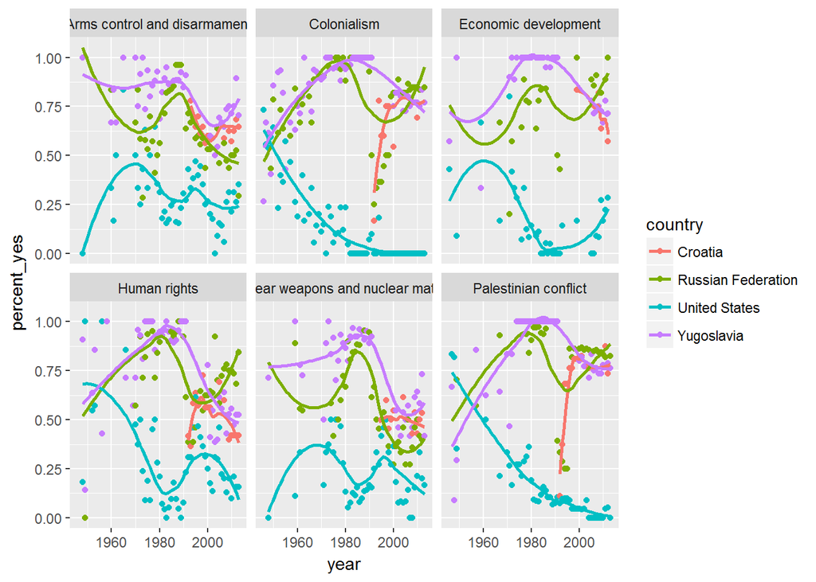

```r
joined %>%
  filter(country %in% c("Croatia", "United States", "Russian Federation", "Yugoslavia")) %>%
  inner_join(un_roll_call_issues, by = "rcid") %>%
  group_by(year = year(date), country, issue) %>%
  summarize(votes = n(),
            percent_yes = mean(vote == "yes")) %>%
  filter(votes > 5) %>%
  ggplot(aes(year, percent_yes, col = country)) +
  geom_point() +
  geom_smooth(se = FALSE) +
  facet_wrap(~ issue)
```

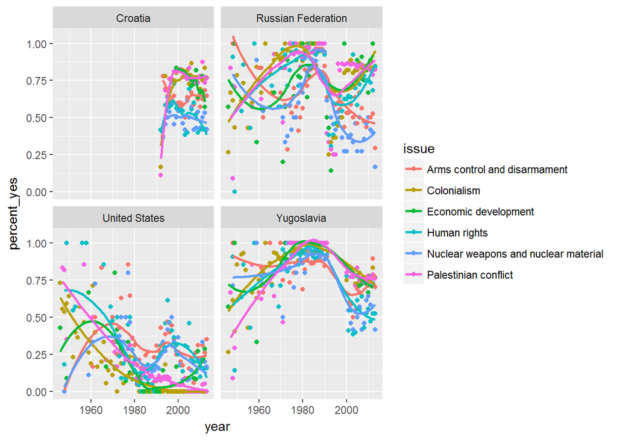

```r
#Da probamo i sa drugacijim rasporedom
joined %>%
  filter(country %in% c("Croatia", "United States", "Russian Federation", "Yugoslavia")) %>%
  inner_join(un_roll_call_issues, by = "rcid") %>%
  group_by(year = year(date), country, issue) %>%
  summarize(votes = n(),
            percent_yes = mean(vote == "yes")) %>%
  filter(votes > 5) %>%
  ggplot(aes(year, percent_yes, col = issue)) +
  geom_point() +
  geom_smooth(se = FALSE) +
  facet_wrap(~ country)
```